# Analisis Harga Rumah dengan Pendekatan CRISP-DM

Studi Kasus Dataset Ames Housing

Yumna Haya Aqilah

12 November 2026

```r
library(AmesHousing)   # sumber dataset Ames Housing
library(dplyr)         # manipulasi data
library(tidyr)         # penataan data
library(ggplot2)       # visualisasi
library(corrplot)      # visualisasi korelasi
library(rpart)         # pohon keputusan (Decision Tree)
library(rpart.plot)    # visualisasi pohon keputusan
library(cluster)       # evaluasi silhouette
library(knitr)         # tabel dan knit

theme_set(theme_minimal(base_family = "serif", base_size = 11))
set.seed(123)

# Helper untuk menulis nama variabel sebagai kode di teks inline
kode <- function(x) paste0("`", x, "`", collapse = ", ")
```

# 1 Business Understanding

## 1.1 Permasalahan Bisnis

Penentuan harga jual rumah merupakan salah satu persoalan yang paling fundamental sekaligus paling sulit di industri properti. Penjual, pembeli, agen, hingga lembaga pembiayaan kerap menghadapi ketidakpastian dalam menilai apakah harga sebuah properti sudah wajar. Penetapan harga yang terlalu tinggi memperlambat penjualan, sementara harga yang terlalu rendah menyebabkan potensi kerugian. Permasalahan inti yang diangkat dalam laporan ini adalah bagaimana memodelkan dan memahami faktor-faktor yang berasosiasi dengan harga rumah secara objektif berbasis data, sehingga keputusan penetapan harga tidak semata-mata bergantung pada intuisi.

## 1.2 Tujuan Analisis

Analisis ini memiliki tiga tujuan analitis yang saling melengkapi. Pertama, membangun model regresi untuk memprediksi harga rumah (`Sale_Price`) sebagai variabel kontinu sekaligus mengidentifikasi variabel yang paling berpengaruh. Kedua, membangun model klasifikasi untuk menggolongkan rumah ke dalam kategori harga tinggi (*High*) dan rendah (*Low*) sebagai alat bantu pengambilan keputusan yang lebih sederhana. Ketiga, melakukan segmentasi (*clustering*) properti untuk menemukan kelompok-kelompok rumah dengan karakteristik serupa yang berguna untuk strategi pemasaran dan penargetan pasar.

## 1.3 Alasan Penggunaan Dataset Ames Housing

Dataset Ames Housing dipilih karena merupakan salah satu dataset rujukan yang paling kaya dan paling banyak digunakan untuk masalah prediksi harga rumah. Dataset ini mencatat transaksi properti residensial di Ames, Iowa, Amerika Serikat, dengan puluhan atribut yang mencakup dimensi fisik, kualitas, lokasi, hingga fasilitas. Versi yang digunakan diperoleh melalui fungsi `make_ames()` dari paket `AmesHousing`, yaitu versi yang telah diproses dan diberi nama variabel yang mudah dibaca. Laporan ini mengikuti lima fase pertama CRISP-DM (*Business Understanding* sampai *Evaluation*); fase *Deployment* berada di luar cakupan.

# 2 Data Understanding (EDA)

## 2.1 Memuat Dataset dan Dimensi Data

```r
ames <- make_ames()
attr(ames, "spec") <- NULL   # metadata impor readr, tidak relevan untuk analisis
dim_ames <- dim(ames)
cat("Jumlah observasi (baris):", dim_ames[1], "\n")
```

```
Jumlah observasi (baris): 2930
```

```r
cat("Jumlah variabel (kolom):", dim_ames[2], "\n")
```

```
Jumlah variabel (kolom): 81
```

Dataset Ames Housing hasil `make_ames()` memuat **2930 observasi** dan **81 variabel**. Jumlah ini berbeda dari data mentah (`ames_raw`) yang berisi 82 kolom, karena `make_ames()` menghapus kolom `Order`, `PID`, dan `Garage_Yr_Blt` serta menambahkan koordinat `Longitude` dan `Latitude`. Banyaknya atribut memungkinkan eksplorasi faktor penentu harga dari ukuran fisik bangunan hingga kualitas material dan tahun pembangunan.

## 2.2 Struktur Data

```r
str(ames, list.len = 15)
```

```
tibble [2,930 × 81] (S3: tbl_df/tbl/data.frame)
 $ MS_SubClass       : Factor w/ 16 levels "One_Story_1946_and_Newer_All_Styles",..: 1 1 1 1 6 6 12 12 12 6 ...
 $ MS_Zoning         : Factor w/ 7 levels "Floating_Village_Residential",..: 3 2 3 3 3 3 3 3 3 3 ...
 $ Lot_Frontage      : num [1:2930] 141 80 81 93 74 78 41 43 39 60 ...
 $ Lot_Area          : int [1:2930] 31770 11622 14267 11160 13830 9978 4920 5005 5389 7500 ...
 $ Street            : Factor w/ 2 levels "Grvl","Pave": 2 2 2 2 2 2 2 2 2 2 ...
 $ Alley             : Factor w/ 3 levels "Gravel","No_Alley_Access",..: 2 2 2 2 2 2 2 2 2 2 ...
 $ Lot_Shape         : Factor w/ 4 levels "Regular","Slightly_Irregular",..: 2 1 2 1 2 2 1 2 2 1 ...
 $ Land_Contour      : Factor w/ 4 levels "Bnk","HLS","Low",..: 4 4 4 4 4 4 4 2 4 4 ...
 $ Utilities         : Factor w/ 3 levels "AllPub","NoSeWa",..: 1 1 1 1 1 1 1 1 1 1 ...
 $ Lot_Config        : Factor w/ 5 levels "Corner","CulDSac",..: 1 5 1 1 5 5 5 5 5 5 ...
 $ Land_Slope        : Factor w/ 3 levels "Gtl","Mod","Sev": 1 1 1 1 1 1 1 1 1 1 ...
 $ Neighborhood      : Factor w/ 29 levels "North_Ames","College_Creek",..: 1 1 1 1 7 7 17 17 17 7 ...
 $ Condition_1       : Factor w/ 9 levels "Artery","Feedr",..: 3 2 3 3 3 3 3 3 3 3 ...
 $ Condition_2       : Factor w/ 8 levels "Artery","Feedr",..: 3 3 3 3 3 3 3 3 3 3 ...
 $ Bldg_Type         : Factor w/ 5 levels "OneFam","TwoFmCon",..: 1 1 1 1 1 1 5 5 5 1 ...
  [list output truncated]
```

Hasil `str()` di atas ditampilkan terbatas pada 15 variabel pertama. Dataset merupakan objek `tibble` yang memadukan variabel numerik (misalnya `Lot_Frontage` dan `Lot_Area`) dengan banyak variabel bertipe `factor` (misalnya `MS_SubClass` dan `Neighborhood`). Variabel kualitas seperti `Overall_Qual`, yang tidak tampil pada potongan di atas, juga disimpan sebagai *factor* dengan urutan level dari `Very_Poor` hingga `Very_Excellent`, bukan sebagai angka. Implikasinya, variabel ini tidak ikut terbaca pada perhitungan korelasi numerik kecuali dikonversi terlebih dahulu menjadi representasi ordinal.

## 2.3 Ringkasan Statistik

```r
key_vars <- c("Sale_Price", "Gr_Liv_Area", "Total_Bsmt_SF", "Garage_Area",
              "Lot_Area", "Year_Built", "Full_Bath", "TotRms_AbvGrd")
summary(ames[key_vars])
```

```
   Sale_Price      Gr_Liv_Area   Total_Bsmt_SF   Garage_Area        Lot_Area
 Min.   : 12789   Min.   : 334   Min.   :   0   Min.   :   0.0   Min.   :  1300
 1st Qu.:129500   1st Qu.:1126   1st Qu.: 793   1st Qu.: 320.0   1st Qu.:  7440
 Median :160000   Median :1442   Median : 990   Median : 480.0   Median :  9436
 Mean   :180796   Mean   :1500   Mean   :1051   Mean   : 472.7   Mean   : 10148
 3rd Qu.:213500   3rd Qu.:1743   3rd Qu.:1302   3rd Qu.: 576.0   3rd Qu.: 11555
 Max.   :755000   Max.   :5642   Max.   :6110   Max.   :1488.0   Max.   :215245
   Year_Built     Full_Bath     TotRms_AbvGrd
 Min.   :1872   Min.   :0.000   Min.   : 2.000
 1st Qu.:1954   1st Qu.:1.000   1st Qu.: 5.000
 Median :1973   Median :2.000   Median : 6.000
 Mean   :1971   Mean   :1.567   Mean   : 6.443
 3rd Qu.:2001   3rd Qu.:2.000   3rd Qu.: 7.000
 Max.   :2010   Max.   :4.000   Max.   :15.000
```

Ringkasan statistik difokuskan pada variabel kunci agar tetap terbaca. `Sale_Price` memiliki rentang yang sangat lebar dengan rata-rata lebih tinggi daripada median, indikasi awal kemiringan ke kanan (*right-skewed*) akibat sejumlah rumah berharga sangat mahal. Pola serupa tampak pada `Lot_Area`, di mana selisih besar antara kuartil ketiga dan nilai maksimum menandakan *outlier* berupa lahan yang sangat luas.

## 2.4 Analisis Missing Value

```r
total_na <- sum(is.na(ames))
na_per_col <- colSums(is.na(ames))
cat("Total missing value pada seluruh dataset:", total_na, "\n")
```

```
Total missing value pada seluruh dataset: 0
```

```r
cat("Jumlah variabel yang mengandung missing value:", sum(na_per_col > 0), "\n")
```

```
Jumlah variabel yang mengandung missing value: 0
```

```r
# make_ames() tidak menyisakan NA karena mengodekan ulang nilai yang hilang.
# Perbandingan dengan data mentah menunjukkan bagaimana hal itu dilakukan.
na_raw_lf <- sum(is.na(ames_raw$`Lot Frontage`))
zero_lf   <- sum(ames$Lot_Frontage == 0)
na_raw_mv <- sum(is.na(ames_raw$`Mas Vnr Area`))
zero_mv_from_na <- sum(ames$Mas_Vnr_Area[is.na(ames_raw$`Mas Vnr Area`)] == 0)

kable(data.frame(
  Variabel = c("Lot_Frontage", "Mas_Vnr_Area"),
  NA_di_ames_raw = c(na_raw_lf, na_raw_mv),
  Menjadi_nol_di_make_ames = c(zero_lf, zero_mv_from_na)
), caption = "Pengodean Ulang Missing Value oleh make_ames()")
```

Pengodean Ulang Missing Value oleh make_ames()

| Variabel | NA_di_ames_raw | Menjadi_nol_di_make_ames |
| --- | --- | --- |
| Lot_Frontage | 490 | 490 |
| Mas_Vnr_Area | 23 | 23 |

Dataset hasil `make_ames()` **tidak memiliki missing value** (total 0). Namun ketiadaan NA ini bukan berarti datanya lengkap: `make_ames()` mengodekan ulang nilai yang hilang, misalnya menjadi kategori seperti `No_Garage` atau menjadi angka 0. Tabel di atas menunjukkan 490 nilai `Lot Frontage` yang hilang di data mentah tercatat sebagai 0, dan 23 nilai `Mas Vnr Area` yang hilang juga menjadi 0. `Lot_Frontage` tidak dipakai dalam model, tetapi `Mas_Vnr_Area` dipakai, sehingga 23 rumah tersebut diperlakukan sebagai rumah tanpa *masonry veneer*. Karena jumlahnya kecil (kurang dari 1% data), pengodean ini dibiarkan dan dicatat sebagai keterbatasan.

## 2.5 Distribusi Harga Rumah

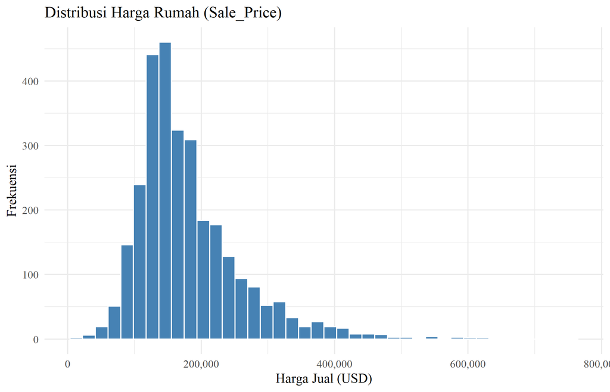

```r
ggplot(ames, aes(x = Sale_Price)) +
  geom_histogram(bins = 40, fill = "steelblue", color = "white") +
  scale_x_continuous(labels = scales::comma) +
  labs(title = "Distribusi Harga Rumah (Sale_Price)",
       x = "Harga Jual (USD)", y = "Frekuensi")
```

Histogram memperkuat dugaan bahwa distribusi `Sale_Price` menceng ke kanan. Mayoritas rumah terkonsentrasi pada rentang harga menengah, sementara ekor panjang ke arah harga tinggi ditempati sejumlah kecil properti mahal. Distribusi seperti ini berpotensi melanggar asumsi kenormalan residual pada regresi linier dan dapat menurunkan akurasi prediksi pada segmen harga ekstrem.

## 2.6 Boxplot Harga Rumah

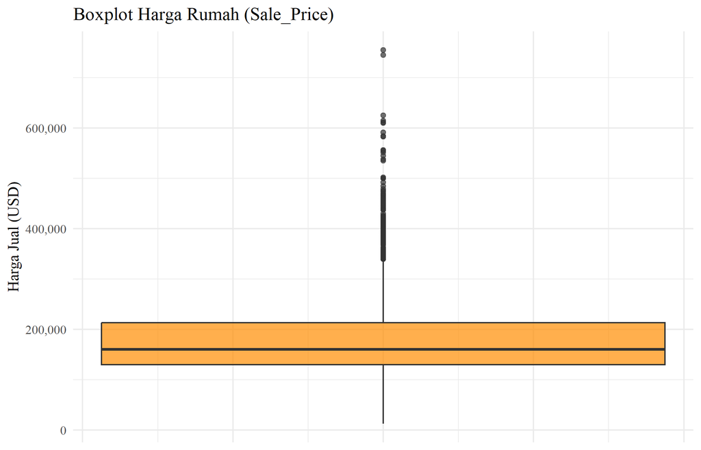

```r
ggplot(ames, aes(y = Sale_Price)) +
  geom_boxplot(fill = "darkorange", alpha = 0.7) +
  scale_y_continuous(labels = scales::comma) +
  labs(title = "Boxplot Harga Rumah (Sale_Price)", y = "Harga Jual (USD)") +
  theme(axis.text.x = element_blank())
```

Boxplot menunjukkan banyak titik *outlier* di atas batas pagar atas (*upper whisker*), yaitu rumah dengan harga jauh di atas mayoritas pasar. *Outlier* ini merepresentasikan segmen properti premium yang nyata, bukan sekadar gangguan statistik. Akibatnya, metrik berbasis kuadrat galat seperti RMSE dapat didominasi oleh segelintir properti mahal.

## 2.7 Korelasi Variabel Numerik

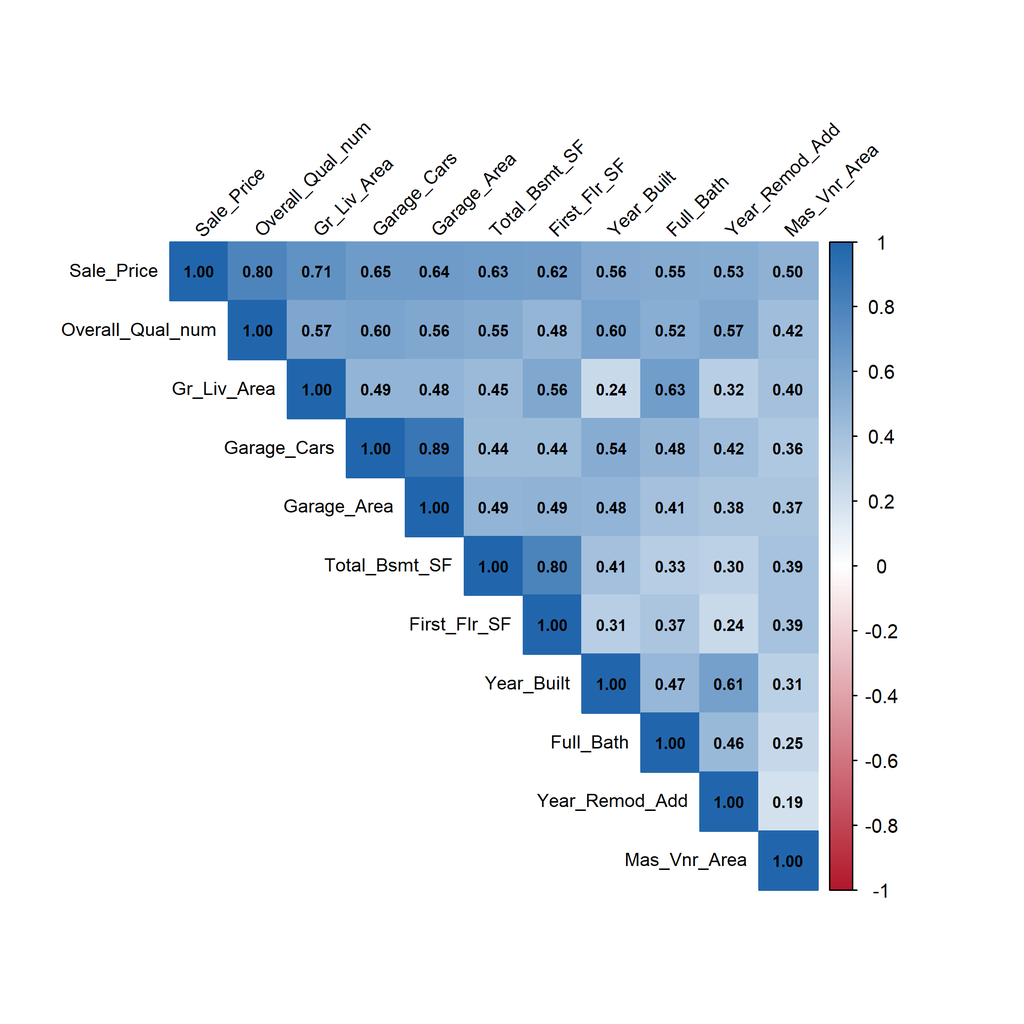

```r
# Konversi variabel kualitas ordinal menjadi numerik agar ikut dianalisis
ames_cor <- ames %>%
  mutate(Overall_Qual_num = as.integer(Overall_Qual),
         Overall_Cond_num = as.integer(Overall_Cond)) %>%
  select(where(is.numeric))

cor_mat <- cor(ames_cor, use = "complete.obs")

# Variabel yang paling berkorelasi dengan Sale_Price untuk heatmap
cor_sp_all <- sort(cor_mat[, "Sale_Price"], decreasing = TRUE)
top_vars <- names(cor_sp_all)[1:11]
corrplot(cor_mat[top_vars, top_vars],
         method = "color", type = "upper",
         tl.col = "black", tl.cex = 0.75, tl.srt = 45,
         addCoef.col = "black", number.cex = 0.65,
         col = colorRampPalette(c("#B2182B", "white", "#2166AC"))(200))
```

Heatmap korelasi menampilkan hubungan antar variabel numerik yang paling kuat berasosiasi dengan harga. `Overall_Qual` (kualitas bangunan keseluruhan) memiliki korelasi positif paling kuat terhadap `Sale_Price` (r = 0.80), diikuti variabel ukuran seperti `Gr_Liv_Area` dan kapasitas garasi. Heatmap juga memperlihatkan bahwa beberapa prediktor saling berkorelasi tinggi, misalnya `Garage_Cars` dengan `Garage_Area` (r = 0.89) dan `Total_Bsmt_SF` dengan `First_Flr_SF` (r = 0.80).

## 2.8 Sepuluh Variabel Paling Berkorelasi dengan Harga

```r
top10 <- cor_sp_all[2:11]   # indeks 1 adalah Sale_Price terhadap dirinya sendiri
top10_df <- data.frame(Variabel = names(top10),
                       Korelasi = round(as.numeric(top10), 3))
kable(top10_df, caption = "Sepuluh Variabel dengan Korelasi Tertinggi terhadap Sale_Price")
```

Sepuluh Variabel dengan Korelasi Tertinggi terhadap Sale_Price

| Variabel | Korelasi |
| --- | --- |
| Overall_Qual_num | 0.799 |
| Gr_Liv_Area | 0.707 |
| Garage_Cars | 0.648 |
| Garage_Area | 0.640 |
| Total_Bsmt_SF | 0.633 |
| First_Flr_SF | 0.622 |
| Year_Built | 0.558 |
| Full_Bath | 0.546 |
| Year_Remod_Add | 0.533 |
| Mas_Vnr_Area | 0.502 |

```r
# Daftar ini dipakai kembali secara identik pada sanity check dan pemodelan.
top_predictors <- names(top10)
```

Tabel di atas memeringkat sepuluh variabel dengan korelasi tertinggi terhadap `Sale_Price`. `Overall_Qual` berada di puncak, diikuti variabel ukuran fisik (`Gr_Liv_Area`, `Garage_Cars`, `Garage_Area`, `Total_Bsmt_SF`). Polanya koheren: harga rumah di Ames terutama berasosiasi dengan dua dimensi, yaitu *kualitas bangunan* dan *luas ruang*. Variabel temporal seperti `Year_Built` juga muncul, menandakan rumah yang lebih baru cenderung berharga lebih tinggi. Daftar ini menjadi dasar pemilihan prediktor pada tahap pemodelan.

## 2.9 Hubungan Luas Rumah dan Harga

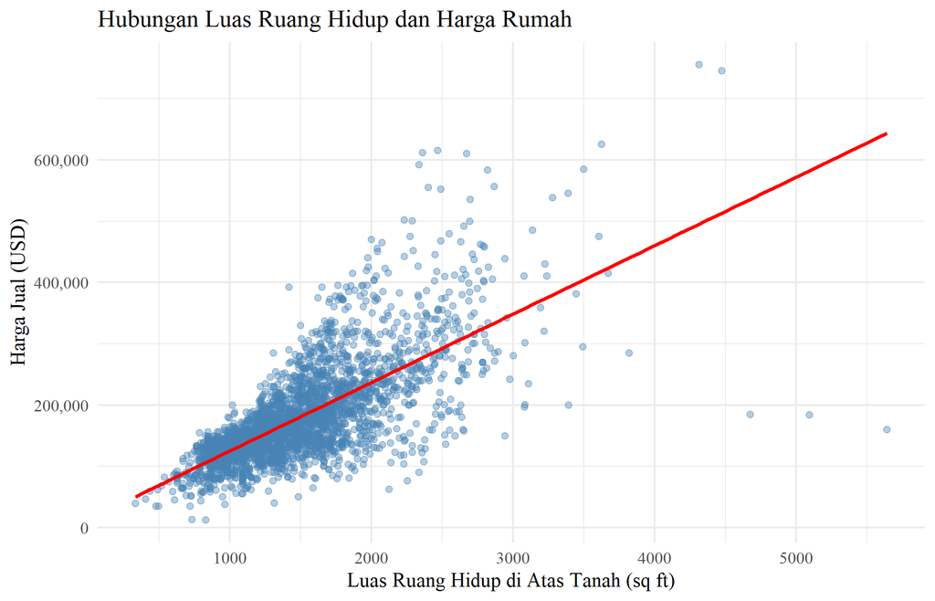

```r
p_area <- ggplot(ames, aes(x = Gr_Liv_Area, y = Sale_Price)) +
  geom_point(alpha = 0.4, color = "steelblue") +
  geom_smooth(method = "lm", color = "red", se = FALSE) +
  scale_y_continuous(labels = scales::comma) +
  labs(title = "Hubungan Luas Ruang Hidup dan Harga Rumah",
       x = "Luas Ruang Hidup di Atas Tanah (sq ft)", y = "Harga Jual (USD)")
p_area
```

Scatterplot memperlihatkan hubungan linier positif yang cukup tegas antara luas ruang hidup (`Gr_Liv_Area`) dan harga jual. Sebaran titik melebar pada luas yang besar, menandakan luas saja tidak cukup menjelaskan harga properti besar; kualitas dan lokasi kemungkinan turut berperan. Terdapat pula beberapa titik dengan luas sangat besar namun harga relatif rendah. Titik-titik ini merupakan kandidat *influential outlier* yang dapat menarik garis regresi dan dibahas kembali pada tahap pemodelan.

## 2.10 Harga Rumah Berdasarkan Kualitas Bangunan

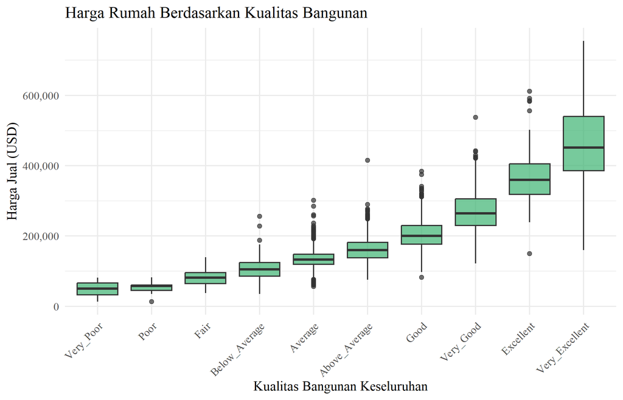

```r
p_quality <- ggplot(ames, aes(x = Overall_Qual, y = Sale_Price)) +
  geom_boxplot(fill = "mediumseagreen", alpha = 0.7) +
  scale_y_continuous(labels = scales::comma) +
  labs(title = "Harga Rumah Berdasarkan Kualitas Bangunan",
       x = "Kualitas Bangunan Keseluruhan", y = "Harga Jual (USD)") +
  theme(axis.text.x = element_text(angle = 45, hjust = 1))
p_quality
```

Visualisasi ini menunjukkan gradasi harga yang monoton seiring meningkatnya kualitas bangunan: median harga pada kategori `Very_Excellent` berkali lipat lebih tinggi dibanding kategori `Average` ke bawah. Pola berjenjang ini mengonfirmasi bahwa hubungan `Overall_Qual` dengan harga terstruktur dan dapat ditafsirkan. Rentang interkuartil yang membesar pada kategori kualitas tinggi juga menunjukkan bahwa variabilitas harga rumah premium jauh lebih besar.

# 3 Data Preparation

## 3.1 Penanganan Missing Value

```r
ames_clean <- ames %>% drop_na()
cat("Jumlah baris sebelum penanganan NA:", nrow(ames), "\n")
```

```
Jumlah baris sebelum penanganan NA: 2930
```

```r
cat("Jumlah baris sesudah penanganan NA:", nrow(ames_clean), "\n")
```

```
Jumlah baris sesudah penanganan NA: 2930
```

Karena tidak ada NA, `drop_na()` tidak menghapus observasi apa pun. Langkah ini dipertahankan sebagai pengaman jika sumber data berubah.

## 3.2 Deteksi dan Penanganan Duplikasi

```r
n_dup <- sum(duplicated(ames_clean))
cat("Jumlah baris duplikat terdeteksi:", n_dup, "\n")
```

```
Jumlah baris duplikat terdeteksi: 0
```

```r
# Menghapus baris duplikat bila ada (mempertahankan satu salinan)
ames_clean <- dplyr::distinct(ames_clean)
cat("Jumlah baris setelah penghapusan duplikat:", nrow(ames_clean), "\n")
```

```
Jumlah baris setelah penghapusan duplikat: 2930
```

Tidak ditemukan baris duplikat, sehingga `distinct()` tidak menghapus observasi apa pun.

## 3.3 Validasi Nilai Tidak Wajar (Sanity Check)

```r
# Pemeriksaan rentang untuk seluruh variabel model (top_predictors) dan target.
# Overall_Qual_num dikecualikan karena merupakan encoding dari factor yang sudah bersih.
sanity_vars <- c("Sale_Price", setdiff(top_predictors, "Overall_Qual_num"))

# Variabel yang boleh bernilai 0 (0 = fitur memang tidak ada)
boleh_nol <- c("Garage_Cars", "Garage_Area", "Total_Bsmt_SF", "Full_Bath",
               "Mas_Vnr_Area", "Half_Bath", "Fireplaces")
must_positive <- setdiff(sanity_vars, boleh_nol)   # harus > 0
non_negative  <- intersect(sanity_vars, boleh_nol) # boleh = 0, tidak boleh < 0

cek_positif <- sapply(must_positive, function(v) sum(ames_clean[[v]] <= 0, na.rm = TRUE))
cek_negatif <- sapply(non_negative, function(v) sum(ames_clean[[v]] < 0, na.rm = TRUE))

cat("Variabel yang harus positif:\n"); print(cek_positif)
```

```
Variabel yang harus positif:
```

```
    Sale_Price    Gr_Liv_Area   First_Flr_SF     Year_Built Year_Remod_Add
             0              0              0              0              0
```

```r
cat("\nVariabel yang boleh nol:\n"); print(cek_negatif)
```

```
Variabel yang boleh nol:
```

```
  Garage_Cars   Garage_Area Total_Bsmt_SF     Full_Bath  Mas_Vnr_Area
            0             0             0             0             0
```

```r
# Penanganan: imputasi nilai tidak wajar dengan median (robust terhadap outlier)
total_imputasi <- 0
for (v in must_positive) {
  bad <- which(ames_clean[[v]] <= 0)
  if (length(bad) > 0) {
    ames_clean[[v]][bad] <- median(ames_clean[[v]][ames_clean[[v]] > 0], na.rm = TRUE)
    total_imputasi <- total_imputasi + length(bad)
  }
}
for (v in non_negative) {
  bad <- which(ames_clean[[v]] < 0)
  if (length(bad) > 0) {
    ames_clean[[v]][bad] <- median(ames_clean[[v]][ames_clean[[v]] >= 0], na.rm = TRUE)
    total_imputasi <- total_imputasi + length(bad)
  }
}
cat("\nTotal nilai tidak wajar yang diimputasi dengan median:", total_imputasi, "\n")
```

```
Total nilai tidak wajar yang diimputasi dengan median: 0
```

```r
# Pemeriksaan konsistensi antarvariabel. Hanya dilaporkan, data tidak diubah.
n_remod_before_built <- sum(ames_clean$Year_Remod_Add < ames_clean$Year_Built)
n_built_after_sold   <- sum(ames_clean$Year_Built > ames_clean$Year_Sold)
n_garage_mismatch    <- sum((ames_clean$Garage_Cars == 0) != (ames_clean$Garage_Area == 0))

kable(data.frame(
  Pemeriksaan = c("Tahun renovasi lebih awal dari tahun dibangun",
                  "Tahun dibangun lebih akhir dari tahun terjual",
                  "Garage_Cars = 0 tidak sejalan dengan Garage_Area = 0"),
  Jumlah_Baris = c(n_remod_before_built, n_built_after_sold, n_garage_mismatch)
), caption = "Pemeriksaan Konsistensi Antarvariabel")
```

Pemeriksaan Konsistensi Antarvariabel

| Pemeriksaan | Jumlah_Baris |
| --- | --- |
| Tahun renovasi lebih awal dari tahun dibangun | 1 |
| Tahun dibangun lebih akhir dari tahun terjual | 1 |
| Garage_Cars = 0 tidak sejalan dengan Garage_Area = 0 | 0 |

```r
# Dataset bersih final diteruskan ke tahap pemodelan
ames <- ames_clean
```

Validasi diterapkan pada sepuluh variabel berkorelasi tertinggi beserta target. Aturan kewajaran dibedakan: `Sale_Price`, `Gr_Liv_Area`, `First_Flr_SF`, dan variabel tahun harus bernilai positif, sedangkan `Garage_Cars`, `Garage_Area`, `Total_Bsmt_SF`, `Full_Bath`, dan `Mas_Vnr_Area` boleh bernilai nol karena nol bermakna substantif (rumah tanpa garasi, basement, kamar mandi penuh, atau veneer batu). Tidak ditemukan nilai di luar rentang, sehingga tidak ada imputasi. Median disiapkan sebagai strategi imputasi karena distribusi harga dan luas sarat *outlier*.

Pemeriksaan konsistensi antarvariabel menemukan 1 rumah dengan tahun renovasi lebih awal dari tahun dibangun dan 1 rumah yang tercatat dibangun setelah tahun terjual (kemungkinan penjualan rumah baru sebelum selesai dibangun). Karena hanya menyangkut dua dari 2930 baris, data dibiarkan apa adanya. Kapasitas garasi (`Garage_Cars`) dan luas garasi (`Garage_Area`) sepenuhnya konsisten.

## 3.4 Pemilihan Variabel dan Encoding

```r
# Bertolak dari 10 variabel paling berkorelasi (top_predictors). Garage_Cars dan
# Garage_Area mengukur hal yang nyaris sama, sehingga Garage_Area dibuang untuk
# mengurangi redundansi. Garage_Cars dipertahankan karena korelasinya sedikit
# lebih tinggi dan lebih mudah ditafsirkan.
ames_model <- ames %>%
  mutate(Overall_Qual_num = as.integer(Overall_Qual),
         Overall_Cond_num = as.integer(Overall_Cond))

model_predictors <- setdiff(top_predictors, "Garage_Area")
model_df <- ames_model %>% select(Sale_Price, all_of(model_predictors))

cat("Variabel prediktor:\n")
```

```
Variabel prediktor:
```

```r
print(model_predictors)
```

```
[1] "Overall_Qual_num" "Gr_Liv_Area"      "Garage_Cars"      "Total_Bsmt_SF"
[5] "First_Flr_SF"     "Year_Built"       "Full_Bath"        "Year_Remod_Add"
[9] "Mas_Vnr_Area"
```

```r
str(model_df, list.len = 10)
```

```
tibble [2,930 × 10] (S3: tbl_df/tbl/data.frame)
 $ Sale_Price      : int [1:2930] 215000 105000 172000 244000 189900 195500 213500 191500 236500 189000 ...
 $ Overall_Qual_num: int [1:2930] 6 5 6 7 5 6 8 8 8 7 ...
 $ Gr_Liv_Area     : int [1:2930] 1656 896 1329 2110 1629 1604 1338 1280 1616 1804 ...
 $ Garage_Cars     : num [1:2930] 2 1 1 2 2 2 2 2 2 2 ...
 $ Total_Bsmt_SF   : num [1:2930] 1080 882 1329 2110 928 ...
 $ First_Flr_SF    : int [1:2930] 1656 896 1329 2110 928 926 1338 1280 1616 1028 ...
 $ Year_Built      : int [1:2930] 1960 1961 1958 1968 1997 1998 2001 1992 1995 1999 ...
 $ Full_Bath       : int [1:2930] 1 1 1 2 2 2 2 2 2 2 ...
 $ Year_Remod_Add  : int [1:2930] 1960 1961 1958 1968 1998 1998 2001 1992 1996 1999 ...
 $ Mas_Vnr_Area    : num [1:2930] 112 0 108 0 0 20 0 0 0 0 ...
```

Prediktor dipilih dari sepuluh variabel numerik dengan korelasi tertinggi terhadap `Sale_Price`, lalu `Garage_Area` dibuang. Alasannya, `Garage_Area` dan `Garage_Cars` mengukur hal yang sama (kapasitas garasi) dengan korelasi 0.89, sehingga memasukkan keduanya terutama menambah redundansi. Dampak keputusan ini terhadap akurasi prediksi diukur pada bagian 4.1.3. Variabel kualitas ordinal (`Overall_Qual`) di-*encode* menjadi integer 1 (`Very_Poor`) sampai 10 (`Very_Excellent`) sesuai urutan levelnya.

## 3.5 Pemilihan Variabel dan Standardisasi untuk Clustering

```r
# Variabel ukuran yang saling berkorelasi (Total_Bsmt_SF, Garage_Area) serta
# Lot_Area yang sarat outlier tidak diikutsertakan.
clust_vars <- ames %>%
  mutate(Overall_Qual_num = as.integer(Overall_Qual)) %>%
  select(Sale_Price, Gr_Liv_Area, Overall_Qual_num)

clust_scaled <- scale(clust_vars)
cat("Rata-rata setiap kolom setelah standardisasi:\n")
```

```
Rata-rata setiap kolom setelah standardisasi:
```

```r
print(round(colMeans(clust_scaled), 4))
```

```
      Sale_Price      Gr_Liv_Area Overall_Qual_num
               0                0                0
```

```r
cat("\nSimpangan baku setiap kolom setelah standardisasi:\n")
```

```
Simpangan baku setiap kolom setelah standardisasi:
```

```r
print(round(apply(clust_scaled, 2, sd), 4))
```

```
      Sale_Price      Gr_Liv_Area Overall_Qual_num
               1                1                1
```

Untuk klastering dipilih tiga variabel yang mewakili tiga dimensi berbeda: harga (`Sale_Price`), ukuran (`Gr_Liv_Area`), dan kualitas (`Overall_Qual`). Variabel ukuran lain seperti `Total_Bsmt_SF` dan `Garage_Area` tidak dimasukkan karena berkorelasi tinggi dengan ukuran lain sehingga akan menggandakan bobot dimensi ukuran, sedangkan `Lot_Area` dikeluarkan karena *outlier* ekstremnya dapat mendominasi jarak. Perlu dicatat bahwa `Sale_Price` ikut menjadi fitur, sehingga segmen yang terbentuk sebagian besar mencerminkan tingkat harga (dibahas pada bagian 4.3.5). Standardisasi ke skor-z wajib karena K-Means memakai jarak Euclidean yang sensitif terhadap skala; output di atas mengonfirmasi setiap variabel memiliki rata-rata nol dan simpangan baku satu.

## 3.6 Pembuatan Label Klasifikasi

```r
median_price <- median(model_df$Sale_Price)
model_df$Price_Class <- factor(
  ifelse(model_df$Sale_Price > median_price, "High", "Low"),
  levels = c("Low", "High")
)
cat("Nilai median Sale_Price sebagai ambang batas:", median_price, "\n")
```

```
Nilai median Sale_Price sebagai ambang batas: 160000
```

```r
print(table(model_df$Price_Class))
```

```
 Low High
1467 1463
```

Label klasifikasi `Price_Class` dibentuk dengan membagi rumah menjadi kategori *High* dan *Low* berdasarkan median `Sale_Price` (USD 160,000). Median dipilih karena distribusi harga yang menceng membuat rata-rata tertarik oleh *outlier*, dan median menghasilkan dua kelas yang nyaris seimbang. Keseimbangan kelas ini membuat akurasi tetap bermakna sebagai metrik evaluasi.

## 3.7 Split Data Train-Test

```r
set.seed(123)
n <- nrow(model_df)
train_idx <- sample(seq_len(n), size = floor(0.8 * n))
train <- model_df[train_idx, ]
test  <- model_df[-train_idx, ]
cat("Jumlah data latih:", nrow(train), "(80%)\n")
```

```
Jumlah data latih: 2344 (80%)
```

```r
cat("Jumlah data uji :", nrow(test), "(20%)\n")
```

```
Jumlah data uji : 586 (20%)
```

Data dibagi secara acak menjadi 80 persen data latih (2344 observasi) dan 20 persen data uji (586 observasi) dengan *seed* tetap untuk reproduktibilitas. Data uji hanya dipakai untuk evaluasi akhir agar estimasi performa tidak terlalu optimistis.

# 4 Modeling

## 4.1 Regresi (Regression)

### 4.1.1 Pembentukan Model dan Ringkasan

```r
train_reg <- train %>% select(-Price_Class)
test_reg  <- test  %>% select(-Price_Class)

lm_model <- lm(Sale_Price ~ ., data = train_reg)
summary(lm_model)
```

```
Call:
lm(formula = Sale_Price ~ ., data = train_reg)

Residuals:
    Min      1Q  Median      3Q     Max
-498356  -18956   -2100   15428  288460

Coefficients:
                   Estimate Std. Error t value Pr(>|t|)
(Intercept)      -1.265e+06  9.699e+04 -13.042  < 2e-16 ***
Overall_Qual_num  1.910e+04  8.799e+02  21.707  < 2e-16 ***
Gr_Liv_Area       4.964e+01  2.428e+00  20.444  < 2e-16 ***
Garage_Cars       1.195e+04  1.343e+03   8.891  < 2e-16 ***
Total_Bsmt_SF     2.058e+01  3.030e+00   6.792 1.40e-11 ***
First_Flr_SF      1.317e+01  3.480e+00   3.786 0.000157 ***
Year_Built        2.562e+02  3.848e+01   6.659 3.43e-11 ***
Full_Bath        -8.005e+03  1.978e+03  -4.048 5.34e-05 ***
Year_Remod_Add    3.527e+02  4.907e+01   7.187 8.87e-13 ***
Mas_Vnr_Area      4.281e+01  4.928e+00   8.688  < 2e-16 ***
---
Signif. codes:  0 '***' 0.001 '**' 0.01 '*' 0.05 '.' 0.1 ' ' 1

Residual standard error: 36190 on 2334 degrees of freedom
Multiple R-squared:  0.7987,    Adjusted R-squared:  0.7979
F-statistic:  1029 on 9 and 2334 DF,  p-value: < 2.2e-16
```

```r
# Variance Inflation Factor dihitung manual: VIF_j = 1 / (1 - R^2_j),
# dengan R^2_j dari regresi prediktor j terhadap prediktor lainnya.
X_train <- train_reg %>% select(-Sale_Price)
vif_vals <- sapply(names(X_train), function(v) {
  r2_j <- summary(lm(reformulate(setdiff(names(X_train), v), response = v),
                     data = X_train))$r.squared
  1 / (1 - r2_j)
})
kable(data.frame(Variabel = names(vif_vals), VIF = round(vif_vals, 2)),
      row.names = FALSE, caption = "Variance Inflation Factor (VIF) Prediktor Regresi")
```

Variance Inflation Factor (VIF) Prediktor Regresi

| Variabel | VIF |
| --- | --- |
| Overall_Qual_num | 2.78 |
| Gr_Liv_Area | 2.73 |
| Garage_Cars | 1.88 |
| Total_Bsmt_SF | 3.26 |
| First_Flr_SF | 3.36 |
| Year_Built | 2.40 |
| Full_Bath | 2.12 |
| Year_Remod_Add | 1.88 |
| Mas_Vnr_Area | 1.40 |

```r
coef_lm   <- coef(summary(lm_model))
n_pos     <- sum(coef_lm[-1, "Estimate"] > 0)
max_p     <- max(coef_lm[-1, "Pr(>|t|)"])
ci_qual   <- confint(lm_model)["Overall_Qual_num", ]
```

Satu-satunya koefisien negatif adalah `Full_Bath`, padahal korelasinya dengan harga positif. Nilai VIF semua prediktor berada di bawah 5 (tertinggi 3.36 pada `First_Flr_SF`), sehingga tanda negatif ini tidak dapat dijelaskan sebagai multikolinearitas berat. Tafsiran yang lebih tepat adalah efek parsial: pada luas ruang hidup yang sama, rumah dengan lebih banyak kamar mandi penuh menyisakan ruang lain yang lebih sempit. Koefisien individual seperti ini perlu ditafsirkan sebagai asosiasi bersyarat, bukan efek kausal.

### 4.1.2 Prediksi dan Evaluasi Metrik

```r
pred_reg <- predict(lm_model, newdata = test_reg)
aktual   <- test_reg$Sale_Price

rmse <- sqrt(mean((aktual - pred_reg)^2))
mae  <- mean(abs(aktual - pred_reg))
r2   <- 1 - sum((aktual - pred_reg)^2) / sum((aktual - mean(aktual))^2)

# Baseline: memprediksi setiap rumah dengan rata-rata harga data latih
baseline_rmse <- sqrt(mean((aktual - mean(train_reg$Sale_Price))^2))
baseline_mae  <- mean(abs(aktual - mean(train_reg$Sale_Price)))

hasil_reg <- data.frame(
  Metrik = c("RMSE (USD)", "MAE (USD)", "R-squared"),
  Baseline_Rata_rata = c(format(round(baseline_rmse), big.mark = ","),
                         format(round(baseline_mae), big.mark = ","), "0"),
  Regresi_Linier = c(format(round(rmse), big.mark = ","),
                     format(round(mae), big.mark = ","), format(round(r2, 4), nsmall = 4))
)
kable(hasil_reg, caption = "Metrik Evaluasi Model Regresi pada Data Uji")
```

Metrik Evaluasi Model Regresi pada Data Uji

| Metrik | Baseline_Rata_rata | Regresi_Linier |
| --- | --- | --- |
| RMSE (USD) | 77,451 | 34,464 |
| MAE (USD) | 56,922 | 23,088 |
| R-squared | 0 | 0.7993 |

Pada data uji, model menghasilkan **RMSE USD 34,464**, **MAE USD 23,088**, dan **$R^2$ 0.799**, artinya sekitar 80 persen variasi harga pada data uji dijelaskan oleh model. Sebagai pembanding, baseline yang memprediksi setiap rumah dengan rata-rata harga data latih menghasilkan RMSE USD 77,451, sehingga model menurunkan RMSE sekitar 56 persen. $R^2$ data latih (0.7987) hampir sama dengan $R^2$ data uji, sehingga tidak ada indikasi *overfitting*. MAE setara dengan sekitar 14 persen median harga rumah. RMSE sebesar 1.49 kali MAE menandakan adanya sebagian kecil prediksi dengan galat besar.

```r
# Galat per kuartil harga aktual pada data uji
err_q <- data.frame(aktual = aktual, pred = pred_reg) %>%
  mutate(Kuartil = ntile(aktual, 4), galat = abs(aktual - pred)) %>%
  group_by(Kuartil) %>%
  summarise(n = n(),
            Harga_Min = min(aktual),
            Harga_Max = max(aktual),
            MAE = round(mean(galat)),
            MAPE_persen = round(mean(galat / aktual) * 100, 1),
            .groups = "drop")
kable(err_q, caption = "Galat Prediksi per Kuartil Harga Aktual (Data Uji)")
```

Galat Prediksi per Kuartil Harga Aktual (Data Uji)

| Kuartil | n | Harga_Min | Harga_Max | MAE | MAPE_persen |
| --- | --- | --- | --- | --- | --- |
| 1 | 147 | 50138 | 135000 | 17788 | 16.8 |
| 2 | 147 | 135000 | 169000 | 19496 | 13.0 |
| 3 | 146 | 169500 | 226500 | 21767 | 11.5 |
| 4 | 146 | 226500 | 582933 | 33362 | 10.5 |

```r
# Residual terbesar pada data latih
res_train <- residuals(lm_model)
i_min <- which.min(res_train)
res_min_case <- ames_model[train_idx[i_min], c("Gr_Liv_Area", "Sale_Price", "Sale_Condition")]
n_big_house <- sum(ames$Gr_Liv_Area > 4000)
```

Tabel galat per kuartil memperjelas di mana model lemah. Dalam satuan dolar, galat terbesar terjadi pada kuartil harga tertinggi (MAE USD 33,362 dibanding USD 17,788 pada kuartil terendah). Namun secara relatif, galat justru paling besar pada rumah termurah (MAPE 16.8 persen) dan paling kecil pada rumah termahal (MAPE 10.5 persen). Residual paling ekstrem di data latih (USD -498,356) berasal dari rumah seluas 5,642 sq ft yang terjual USD 160,000 dengan kondisi penjualan Partial. Rumah ini termasuk 5 rumah dengan luas di atas 4,000 sq ft yang teridentifikasi sebagai kandidat *influential outlier* pada EDA. Rumah-rumah tersebut tidak dihapus dalam analisis ini.

### 4.1.3 Dampak Membuang Garage_Area

```r
# Membandingkan model 10 prediktor (dengan Garage_Area) dan model utama (9 prediktor).
# ames_model dan model_df memiliki urutan baris yang sama, sehingga train_idx berlaku.
rmse_r2 <- function(prediktor) {
  m <- lm(reformulate(prediktor, response = "Sale_Price"), data = ames_model[train_idx, ])
  y <- ames_model$Sale_Price[-train_idx]
  p <- predict(m, newdata = ames_model[-train_idx, ])
  c(RMSE = sqrt(mean((y - p)^2)), R2 = 1 - sum((y - p)^2) / sum((y - mean(y))^2))
}
garage_cmp <- rbind(rmse_r2(top_predictors), rmse_r2(model_predictors))
kable(data.frame(
  Model = c("Dengan Garage_Area (10 prediktor)", "Tanpa Garage_Area (9 prediktor, model utama)"),
  RMSE_USD = format(round(garage_cmp[, "RMSE"]), big.mark = ","),
  R_squared = round(garage_cmp[, "R2"], 4)
), caption = "Perbandingan Model Dengan dan Tanpa Garage_Area (Data Uji)")
```

Perbandingan Model Dengan dan Tanpa Garage_Area (Data Uji)

| Model | RMSE_USD | R_squared |
| --- | --- | --- |
| Dengan Garage_Area (10 prediktor) | 34,251 | 0.8017 |
| Tanpa Garage_Area (9 prediktor, model utama) | 34,464 | 0.7993 |

Membuang `Garage_Area` sedikit menurunkan akurasi pada data uji: RMSE naik dari USD 34,251 menjadi USD 34,464 dan $R^2$ turun dari 0.802 menjadi 0.799. Selisih ini kecil, sehingga model 9 prediktor tetap dipakai karena lebih ringkas dan koefisien garasinya lebih mudah ditafsirkan. Perbandingan ini dilaporkan sebagai konsekuensi keputusan, bukan sebagai dasar pemilihan, karena memilih fitur berdasarkan data uji akan membuat evaluasi bias.

## 4.2 Klasifikasi (Classification)

### 4.2.1 Pembentukan dan Visualisasi Pohon Keputusan

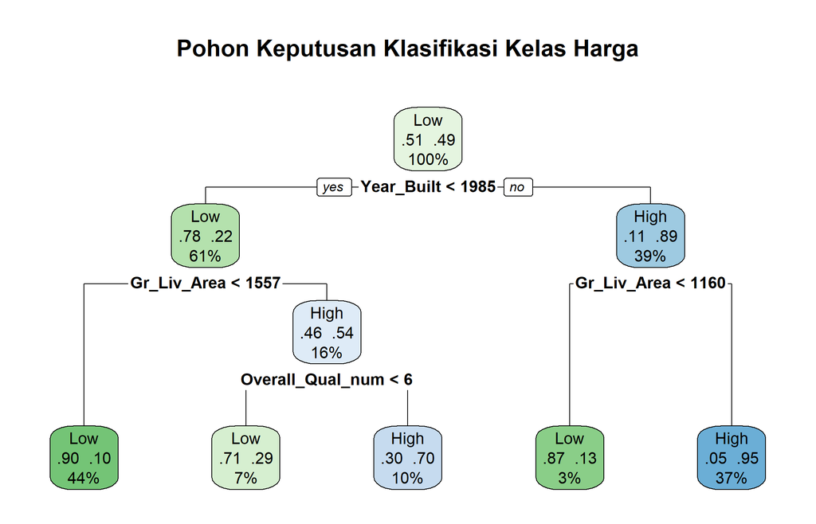

```r
# Sale_Price dikeluarkan untuk menghindari kebocoran target (data leakage),
# karena Price_Class diturunkan langsung dari Sale_Price.
train_clf <- train %>% select(-Sale_Price)
test_clf  <- test  %>% select(-Sale_Price)

tree_model <- rpart(Price_Class ~ ., data = train_clf, method = "class")
rpart.plot(tree_model, type = 2, extra = 104,
           box.palette = "GnBu", fallen.leaves = TRUE,
           main = "Pohon Keputusan Klasifikasi Kelas Harga")
```

```r
# Variable importance rpart juga menghitung kontribusi surrogate split,
# sehingga variabel yang tidak tampil di pohon tetap dapat memiliki nilai.
imp <- tree_model$variable.importance
imp_df <- data.frame(Variabel = names(imp),
                     Importance = round(as.numeric(imp / sum(imp)), 3))
kable(imp_df, row.names = FALSE,
      caption = "Variable Importance Pohon Keputusan (proporsi dari total)")
```

Variable Importance Pohon Keputusan (proporsi dari total)

| Variabel | Importance |
| --- | --- |
| Year_Built | 0.255 |
| Overall_Qual_num | 0.178 |
| Year_Remod_Add | 0.154 |
| Full_Bath | 0.140 |
| Gr_Liv_Area | 0.097 |
| Total_Bsmt_SF | 0.081 |
| Garage_Cars | 0.073 |
| First_Flr_SF | 0.020 |
| Mas_Vnr_Area | 0.003 |

```r
root_var <- as.character(tree_model$frame$var[1])
split_vars <- unique(as.character(tree_model$frame$var[tree_model$frame$var != "<leaf>"]))
```

Hal krusial pada pemodelan klasifikasi ini adalah pengeluaran `Sale_Price` dari prediktor. Karena `Price_Class` diturunkan langsung dari `Sale_Price`, menyertakannya akan menimbulkan kebocoran target (*data leakage*) yang membuat akurasi nyaris sempurna namun tidak bermakna.

Pohon memisahkan data pertama kali berdasarkan `Year_Built` (sebelum atau sesudah 1985), lalu berdasarkan `Gr_Liv_Area` di kedua cabang; `Overall_Qual_num` hanya dipakai di satu cabang untuk rumah lama yang luas. Variabel yang dipakai sebagai pemisah adalah `Year_Built`, `Gr_Liv_Area`, `Overall_Qual_num`. Tabel *variable importance* menunjukkan pola serupa: `Year_Built` (0.255) paling berpengaruh, diikuti `Overall_Qual_num` (0.178) dan `Year_Remod_Add` (0.154). Urutan ini berbeda dari peringkat korelasi karena pohon memilih pemisah yang paling menurunkan *impurity* untuk target biner, bukan korelasi linier dengan harga kontinu. Selain itu, `Year_Built` berkorelasi 0.60 dengan `Overall_Qual`, sehingga keduanya membawa sebagian informasi yang sama. Struktur pohon yang ringkas membuat aturan klasifikasi mudah dibaca oleh pengambil keputusan.

### 4.2.2 Prediksi, Confusion Matrix, dan Metrik Evaluasi

```r
pred_clf <- predict(tree_model, newdata = test_clf, type = "class")
conf_mat <- table(Prediksi = pred_clf, Aktual = test_clf$Price_Class)
print(conf_mat)
```

```
        Aktual
Prediksi Low High
    Low  250   47
    High  15  274
```

```r
# Kelas positif: "High"
TP <- conf_mat["High", "High"]
FP <- conf_mat["High", "Low"]
FN <- conf_mat["Low",  "High"]
TN <- conf_mat["Low",  "Low"]

accuracy  <- (TP + TN) / sum(conf_mat)
precision <- TP / (TP + FP)
recall    <- TP / (TP + FN)
f1        <- 2 * precision * recall / (precision + recall)

metrik_clf <- data.frame(
  Metrik = c("Accuracy", "Precision", "Recall", "F1-Score"),
  Nilai  = round(c(accuracy, precision, recall, f1), 4)
)
kable(metrik_clf, caption = "Metrik Evaluasi Klasifikasi pada Data Uji (kelas positif: High)")
```

Metrik Evaluasi Klasifikasi pada Data Uji (kelas positif: High)

| Metrik | Nilai |
| --- | --- |
| Accuracy | 0.8942 |
| Precision | 0.9481 |
| Recall | 0.8536 |
| F1-Score | 0.8984 |

```r
# Apakah kesalahan klasifikasi berada di dekat ambang median?
salah <- pred_clf != test_clf$Price_Class
jarak_median <- abs(test$Sale_Price - median_price)
med_jarak_salah <- median(jarak_median[salah])
med_jarak_benar <- median(jarak_median[!salah])
share_salah_30k <- mean(jarak_median[salah] <= 30000)

kable(data.frame(
  Kelompok = c("Salah klasifikasi", "Benar klasifikasi"),
  n = c(sum(salah), sum(!salah)),
  Median_Jarak_ke_Ambang_USD = format(c(med_jarak_salah, med_jarak_benar), big.mark = ",")
), caption = "Jarak Harga Aktual ke Ambang Median (Data Uji)")
```

Jarak Harga Aktual ke Ambang Median (Data Uji)

| Kelompok | n | Median_Jarak_ke_Ambang_USD |
| --- | --- | --- |
| Salah klasifikasi | 62 | 14,500 |
| Benar klasifikasi | 524 | 40,000 |

**Akurasi 89.4 persen** menunjukkan proporsi prediksi benar secara keseluruhan, dan karena kedua kelas seimbang, akurasi merupakan metrik yang valid di sini. **Precision 0.948** berarti dari seluruh rumah yang diprediksi *High*, sebagian besar memang berharga tinggi. **Recall 0.854** lebih rendah: model melewatkan 47 rumah berharga tinggi dan memprediksinya sebagai *Low*, sementara hanya 15 rumah murah yang keliru diprediksi *High*. Artinya model cenderung konservatif dalam memberi label *High*. Keduanya terangkum dalam **F1-score 0.898**.

Kesalahan klasifikasi memang terkonsentrasi di dekat ambang. Median jarak harga aktual ke ambang USD 160,000 hanya USD 14,500 untuk rumah yang salah diklasifikasi, dibanding USD 40,000 untuk rumah yang benar. Sebanyak 77 persen kesalahan berada dalam rentang USD 30,000 dari ambang, yaitu zona yang memang paling ambigu.

## 4.3 Klastering (Clustering)

Tujuan klastering adalah mengelompokkan rumah berdasarkan kemiripan karakteristik tanpa label. Algoritma yang digunakan adalah **K-Means**. Berbeda dari regresi dan klasifikasi, klastering tidak memiliki “jawaban benar”, sehingga jumlah klaster (k) ditentukan dengan hati-hati dan kualitasnya dievaluasi dengan metrik internal sebelum hasilnya ditafsirkan.

### 4.3.1 Penentuan Jumlah Cluster (Elbow Method dan Silhouette Score)

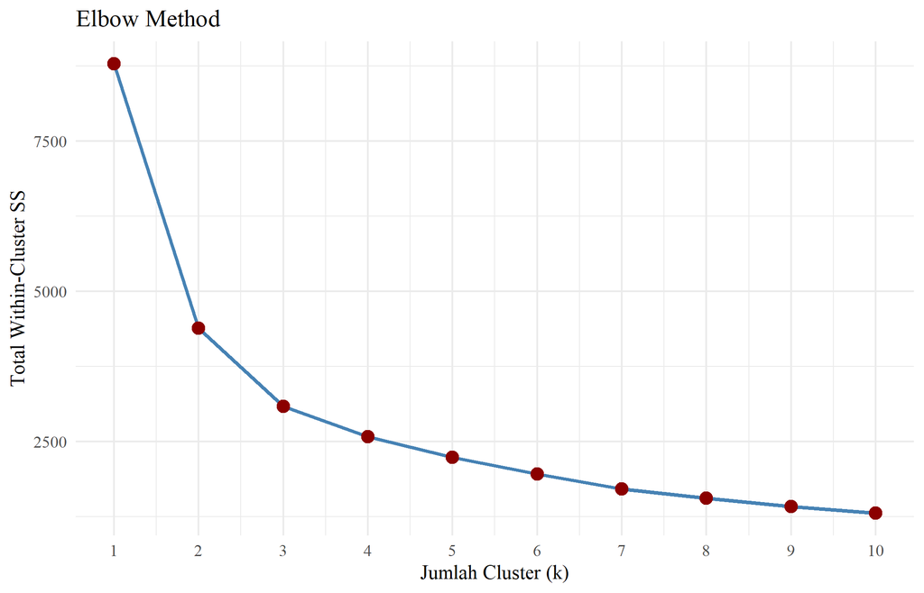

```r
dist_mat <- dist(clust_scaled)

# Elbow Method: total within-cluster sum of squares
set.seed(123)
wss <- sapply(1:10, function(k) {
  kmeans(clust_scaled, centers = k, nstart = 25, iter.max = 50)$tot.withinss
})

# Silhouette rata-rata untuk setiap kandidat k
sil_k <- sapply(2:8, function(k) {
  set.seed(123)
  km <- kmeans(clust_scaled, centers = k, nstart = 25, iter.max = 50)
  mean(silhouette(km$cluster, dist_mat)[, 3])
})

elbow_df <- data.frame(k = 1:10, WSS = wss)
sil_df   <- data.frame(k = 2:8, Silhouette = sil_k)

ggplot(elbow_df, aes(x = k, y = WSS)) +
  geom_line(color = "steelblue", linewidth = 1) +
  geom_point(size = 3, color = "darkred") +
  scale_x_continuous(breaks = 1:10) +
  labs(title = "Elbow Method", x = "Jumlah Cluster (k)",
       y = "Total Within-Cluster SS")
```

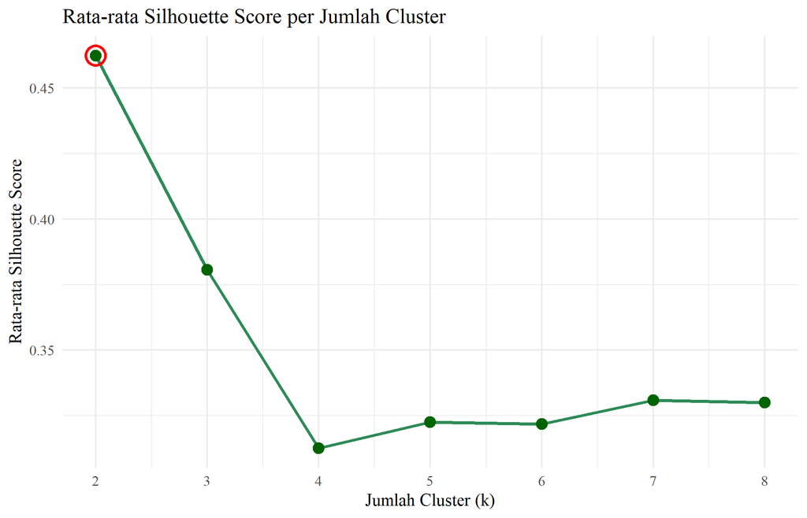

```r
ggplot(sil_df, aes(x = k, y = Silhouette)) +
  geom_line(color = "seagreen", linewidth = 1) +
  geom_point(size = 3, color = "darkgreen") +
  geom_point(data = sil_df[which.max(sil_df$Silhouette), ],
             size = 5, shape = 1, color = "red", stroke = 1.2) +
  scale_x_continuous(breaks = 2:8) +
  labs(title = "Rata-rata Silhouette Score per Jumlah Cluster",
       x = "Jumlah Cluster (k)", y = "Rata-rata Silhouette Score")
```

```r
k_opt <- sil_df$k[which.max(sil_df$Silhouette)]
```

Jumlah klaster ditentukan dari dua kriteria. Kurva **Elbow** menunjukkan penurunan WSS terbesar dari k=1 ke k=2 lalu melandai; pola ini umum dan karena itu bukan bukti kuat dengan sendirinya. **Silhouette Score** memberi dasar yang lebih tegas: nilainya tertinggi pada **k=2** (sekitar 0.462) dan menurun ketika klaster ditambah. Karena itu dipilih k=2. Menambah klaster memang selalu menurunkan WSS, tetapi bila silhouette merosot, klaster tambahan cenderung saling tumpang tindih.

### 4.3.2 Penerapan K-Means dan Jumlah Anggota Cluster

```r
set.seed(123)
km_model <- kmeans(clust_scaled, centers = k_opt, nstart = 25, iter.max = 50)
cat("Jumlah anggota tiap cluster:\n")
```

```
Jumlah anggota tiap cluster:
```

```r
print(table(Cluster = km_model$cluster))
```

```
Cluster
   1    2
1985  945
```

```r
# Satu peta warna agar nomor cluster konsisten di seluruh grafik; mengikuti nilai k
cluster_colors <- setNames(scales::hue_pal()(k_opt), as.character(seq_len(k_opt)))
```

Penerapan K-Means dengan k=2 menghasilkan klaster tanpa klaster mikro yang janggal. Parameter `nstart = 25` menjalankan algoritma dari 25 inisialisasi acak dan memilih solusi terbaik, sehingga mengurangi risiko terperangkap pada optimum lokal.

### 4.3.3 Evaluasi Internal Cluster

```r
wcss <- km_model$tot.withinss   # Total Within-Cluster SS
bss  <- km_model$betweenss      # Between-Cluster SS
tss  <- km_model$totss          # Total SS
ratio_bss <- bss / tss          # Rasio Between SS / Total SS

sil     <- silhouette(km_model$cluster, dist_mat)
avg_sil <- mean(sil[, 3])
sil_per_cluster <- tapply(sil[, 3], sil[, 1], mean)

eval_clust <- data.frame(
  Metrik = c("Total Within-Cluster SS (WCSS)",
             "Between-Cluster SS (BSS)",
             "Total SS (TSS)",
             "Rasio BSS / TSS",
             "Rata-rata Silhouette Score"),
  Nilai  = c(format(round(wcss, 1), nsmall = 1), format(round(bss, 1), nsmall = 1),
             format(round(tss, 1), nsmall = 1),
             format(round(ratio_bss, 4), nsmall = 4), format(round(avg_sil, 4), nsmall = 4))
)
kable(eval_clust, caption = paste0("Metrik Evaluasi Internal Cluster (k = ", k_opt, ")"))
```

Metrik Evaluasi Internal Cluster (k = 2)

| Metrik | Nilai |
| --- | --- |
| Total Within-Cluster SS (WCSS) | 4388.8 |
| Between-Cluster SS (BSS) | 4398.2 |
| Total SS (TSS) | 8787.0 |
| Rasio BSS / TSS | 0.5005 |
| Rata-rata Silhouette Score | 0.4622 |

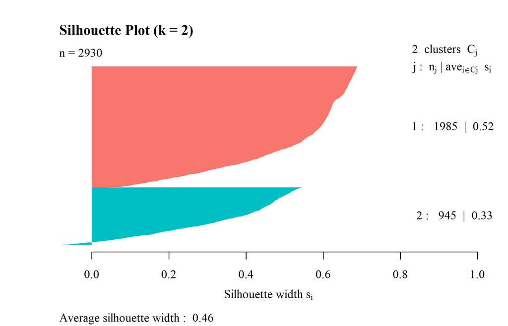

Plot Silhouette untuk Solusi K-Means Terpilih

```r
par(family = "serif")
plot(sil, col = cluster_colors, border = NA,
     main = paste0("Silhouette Plot (k = ", k_opt, ")"))
```

Evaluasi internal dilakukan sebelum profiling agar segmen hanya ditafsirkan bila solusinya layak. Rasio **BSS/TSS 0.501** berarti sekitar 50.1 persen total keragaman dijelaskan oleh pemisahan antar klaster. **Rata-rata Silhouette Score 0.462** tergolong sedang, dan nilainya tidak merata antar klaster (cluster 1: 0.52; cluster 2: 0.33). Nilai sedang ini mencerminkan sifat data properti yang kontinu: harga, ukuran, dan kualitas bergerak dalam spektrum yang mulus, sehingga sebagian rumah berada di zona transisi antar segmen.

### 4.3.4 Visualisasi Cluster dengan PCA

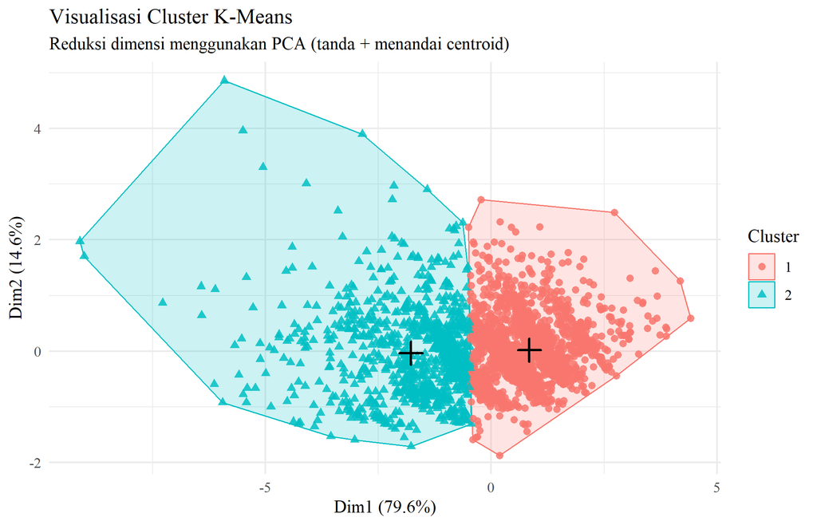

```r
pca <- prcomp(clust_scaled)
var_exp <- summary(pca)$importance[2, 1:2]
pca_df <- data.frame(PC1 = pca$x[, 1], PC2 = pca$x[, 2],
                     Cluster = factor(km_model$cluster))

# Convex hull tiap cluster (area berwarna) dan centroid tiap cluster
hulls <- pca_df %>% group_by(Cluster) %>% slice(chull(PC1, PC2)) %>% ungroup()
centroids <- pca_df %>% group_by(Cluster) %>%
  summarise(PC1 = mean(PC1), PC2 = mean(PC2), .groups = "drop")

p_pca <- ggplot(pca_df, aes(x = PC1, y = PC2, color = Cluster, fill = Cluster)) +
  geom_polygon(data = hulls, alpha = 0.2, linewidth = 0.4) +
  geom_point(aes(shape = Cluster), size = 1.8, alpha = 0.85) +
  geom_point(data = centroids, aes(x = PC1, y = PC2), shape = 3,
             size = 4, stroke = 1.1, color = "black", inherit.aes = FALSE) +
  scale_color_manual(values = cluster_colors) +
  scale_fill_manual(values = cluster_colors) +
  labs(title = "Visualisasi Cluster K-Means",
       subtitle = "Reduksi dimensi menggunakan PCA (tanda + menandai centroid)",
       x = paste0("Dim1 (", round(var_exp[1] * 100, 1), "%)"),
       y = paste0("Dim2 (", round(var_exp[2] * 100, 1), "%)"))
p_pca
```

*Principal Component Analysis* (PCA) dipakai untuk memvisualisasikan klaster pada bidang dua dimensi. Dua komponen pertama menjelaskan **94.3 persen** total variasi, dengan PC1 sendiri menjelaskan 79.6 persen dan merepresentasikan gabungan harga, ukuran, dan kualitas. Karena PC1 begitu dominan, data efektif hampir satu dimensi, dan kedua klaster terutama terpisah di sepanjang sumbu Dim1. Tanda **+** menunjukkan *centroid* tiap klaster. Area pertemuan di tengah serta sebaran titik di sekitar centroid konsisten dengan skor silhouette yang tergolong sedang: klaster terpisah jelas di kedua ujung, tetapi batas di antaranya tidak tegas.

### 4.3.5 Profiling dan Pelabelan Cluster

```r
# Pelabelan berbasis urutan rata-rata harga: klaster termahal = Premium.
cl_price <- tapply(clust_vars$Sale_Price, km_model$cluster, mean)
urutan   <- rank(cl_price, ties.method = "first")
label_text <- if (k_opt == 2) {
  c("Properti Standar/Menengah", "Properti Premium")
} else {
  paste0("Segmen harga ke-", seq_len(k_opt))
}
label_map <- setNames(label_text[urutan], names(cl_price))
stopifnot(!anyNA(label_map))

profil <- clust_vars %>%
  mutate(Cluster = km_model$cluster) %>%
  group_by(Cluster) %>%
  summarise(
    Jumlah        = n(),
    Rata_Harga    = round(mean(Sale_Price)),
    Rata_Luas     = round(mean(Gr_Liv_Area)),
    Rata_Kualitas = round(mean(Overall_Qual_num), 1)
  ) %>%
  mutate(Label = label_map[as.character(Cluster)]) %>%
  arrange(Rata_Harga)

kable(profil, caption = "Profil dan Label Tiap Cluster")
```

Profil dan Label Tiap Cluster

| Cluster | Jumlah | Rata_Harga | Rata_Luas | Rata_Kualitas | Label |
| --- | --- | --- | --- | --- | --- |
| 1 | 1985 | 139818 | 1273 | 5.4 | Properti Standar/Menengah |
| 2 | 945 | 266872 | 1977 | 7.6 | Properti Premium |

```r
# Seberapa mirip segmen K-Means dengan label High/Low dari median harga?
ct <- table(Cluster = label_map[as.character(km_model$cluster)],
            Kelas_Harga = model_df$Price_Class)
print(ct)
```

```
                           Kelas_Harga
Cluster                      Low High
  Properti Premium            15  930
  Properti Standar/Menengah 1452  533
```

```r
kesesuaian <- if (k_opt == 2) {
  (ct["Properti Premium", "High"] + ct["Properti Standar/Menengah", "Low"]) / sum(ct)
} else {
  NA
}
```

Setelah solusi dinyatakan layak, setiap klaster diberi label berdasarkan karakteristik rata-ratanya: klaster dengan rata-rata harga, luas, dan kualitas tertinggi diberi label **“Properti Premium”**, sedangkan klaster lainnya, yang mencakup mayoritas rumah, diberi label **“Properti Standar/Menengah”**. Ketiga variabel bergerak searah, sehingga segmen premium adalah rumah yang lebih besar, lebih berkualitas, dan lebih mahal.

Tabulasi silang dengan label `Price_Class` menunjukkan kedua pembagian sesuai untuk 81.3 persen rumah. Dari 945 rumah di segmen Premium, 930 termasuk kelas *High*, sedangkan segmen Standar/Menengah memuat 533 rumah kelas *High* dan 1452 rumah kelas *Low*. Artinya, karena `Sale_Price` ikut menjadi fitur dan data efektif hampir satu dimensi, segmentasi ini sebagian besar mencerminkan tingkat harga. Nilai tambahnya terutama sebagai profil deskriptif kedua segmen (rata-rata luas dan kualitas), bukan sebagai penemuan kelompok baru yang tidak tertangkap oleh klasifikasi.